# Hawaiian Basalts

Julie M. Coulombe

11/30/2019

## Alkali-Basalt vs Tholeiite

The dataset was pulled from https://search.earthchem.org/ with Feature Name = OceanIsland:Hawaii and Sample Types = igenous:volcanicmafic:alkali.basalt, tholeiite, trachyte, trachytebasalt

```r
alkali_thol <- select(mydata, "SAMPLE.ID", "METHOD":"ZR") %>%
  filter(ROCK.NAME == "ALKALI BASALT" | ROCK.NAME == "THOLEIITE")
cnt_alk <- table(alkali_thol$ROCK.NAME)
cnt_alk
```

```
##
## ALKALI BASALT        BASALT HYALOCLASTITE     THOLEIITE
##             1             0             0            70
```

This data set did not include enough information to analyze - due to only having 1 alkali basalt. When trying to filter for only sio2, that data was not available for any of the observations. At this point I went back to the original database and pulled a new dataset.

```r
alk_thol2 <- select(mydata_2, "SAMPLE.ID", "METHOD":"ZR") %>%
  filter(ROCK.NAME == "ALKALI BASALT" | ROCK.NAME == "THOLEIITE")
cnt_rocks2 <- table(alk_thol2$ROCK.NAME)
cnt_rocks2
```

```
##
## ALKALI BASALT     THOLEIITE  TRACHYBASALT      TRACHYTE
##          1630          4577             0             0
```

This is great - lots of alkali and tholeiite to pull from ## Let’s see if we can plot the elements for alkali and basalt

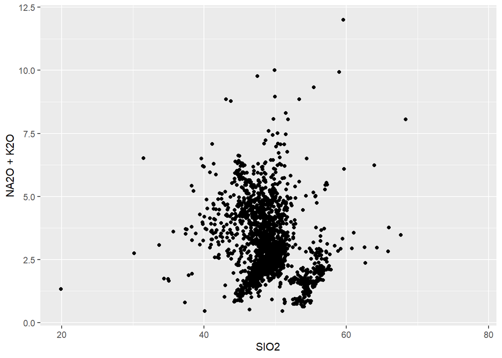

```r
alk_thol_plot <- ggplot(alk_thol2, aes(x = SIO2, y = NA2O + K2O)) +
  geom_point()
alk_thol_plot
```

This plot looks a little crazy - determined that data pull from database did not filter for Hawaii samples only. Let’s try to do this in R

```r
alk_thol3 <- select(mydata_2, "SAMPLE.ID":"TITLE", "METHOD":"ZR") %>%
  filter(grepl("HAWAII", mydata_2$TITLE)) %>%
  filter(ROCK.NAME == "ALKALI BASALT" | ROCK.NAME == "THOLEIITE")
cnt_rocks3 <- table(alk_thol3$ROCK.NAME)
cnt_rocks3
```

```
##
## ALKALI BASALT     THOLEIITE  TRACHYBASALT      TRACHYTE
##             0          1313             0             0
```

so after all that work, it turns out that when filtered to “hawaii”, I am left with no alkali basalt samples to compare against

So let’s look at Hawaii and some major element data, and compare Mg to Si

```r
sio2_sort <- select(mydata_2, "SAMPLE.ID":"TITLE", "METHOD":"ZR") %>%
  filter(mydata_2$SIO2 != "NA") %>%
  filter(grepl("HAWAII", TITLE))
```

and the plot for that filter selection

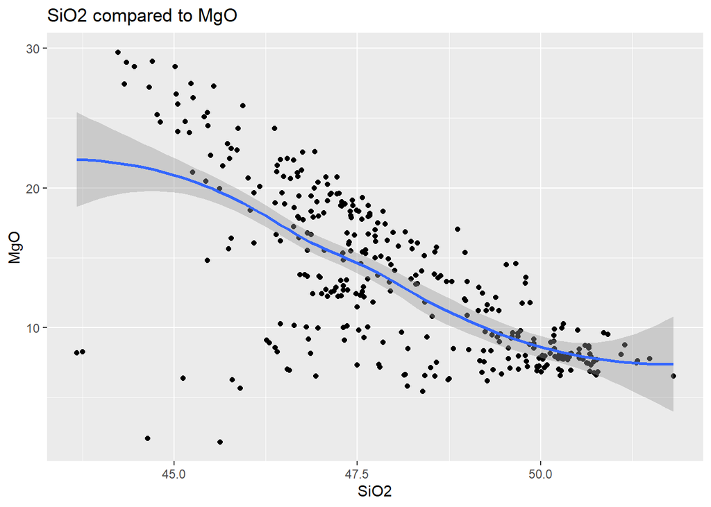

```r
sio2_plot2 <- ggplot(sio2_sort, aes(x = SIO2, y = MGO)) +
  geom_point() +
  geom_smooth() +
  ggtitle("SiO2 compared to MgO") +
  xlab("SiO2") +
  ylab("MgO")
sio2_plot2
```